# College Majors

Thuy Minh Nhan Do

2025-11-12

# Introduction

- College majors shape graduates’ income, job stability, and career trajectory.
- STEM majors are often assumed to earn the most, but the data reveal a more nuanced reality.
- This project explores salaries, unemployment, major size, gender, and income range across fields.

# 1. Dataset

**Dataset:** FiveThirtyEight “College Majors”  
**Source:** [GitHub](https://github.com/fivethirtyeight/data/tree/master/college-majors).

- **all-ages.csv**: Employment & salary for all workers by major.
- **recent-grads.csv**: Outcomes for recent graduates.
- **women-stem.csv**: Gender representation and salaries in STEM majors.

Columns include:

- `Major`
- `Major_category`
- `Total`, `Employed`, `Employed_full_time_year_round`
- `Unemployed`, `Unemployment_rate`
- `Median`
- `P25th`, `P75th`
- `Men`, `Women`, `ShareWomen`

# Why It’s Interesting

- Compare **assumptions vs. reality**: Are STEM majors always highest-paid?
- Explore **gender disparities** in STEM majors.
- Examine **employment outcomes** across majors.
- Identify majors with **unexpectedly high/low salaries or unemployment rates**.
- Investigate **salary ranges (P25–P75)** for income inequality insights.

# Project Focus

We focus on:

1. **Salary trends:** Which majors pay well? Any exceptions?
2. **Employment outcomes:** High-paying majors with high unemployment?
3. **Major size effect:** Does the number of graduates impact outcomes?
4. **Category comparison:** STEM vs. non-STEM fields.
5. **Gender representation** in STEM.
6. **Income range** analysis.
7. **Unemployment comparison:** All workers vs. recent graduates.

# Research Questions

- Which major categories offer the highest median salaries?
- How does median salary relate to unemployment rate across majors?
- Which majors have the top median salaries overall?
- Does major size correlate with unemployment rate?
- How does salary range (P25–P75) differ across majors?
- How does the share of women in STEM relate to median salary?
- How does unemployment differ between all workers and recent graduates?

# Salary by Major Category

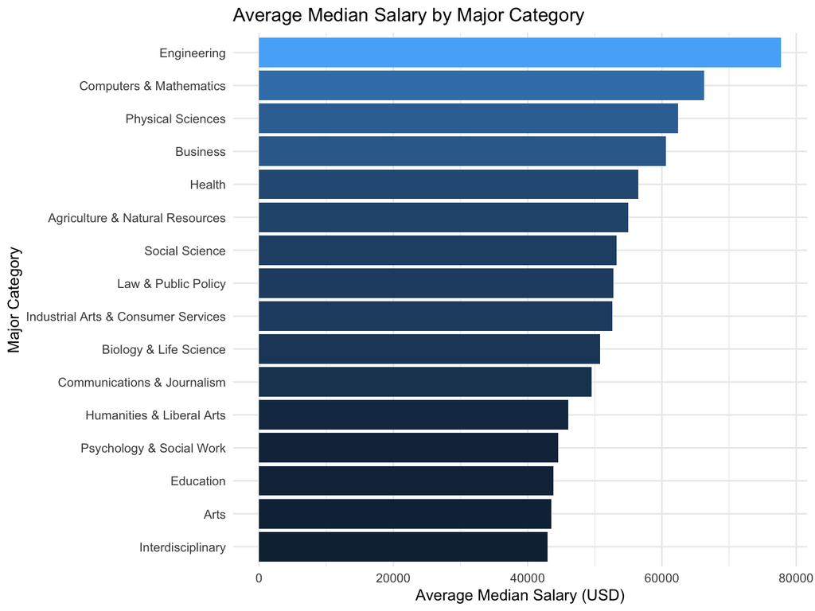

- STEM majors earn the highest overall salaries.
- Business and Healthcare also pay well.
- Humanities and Arts generally have lower earnings.

# Median Salary vs. Unemployment Rate

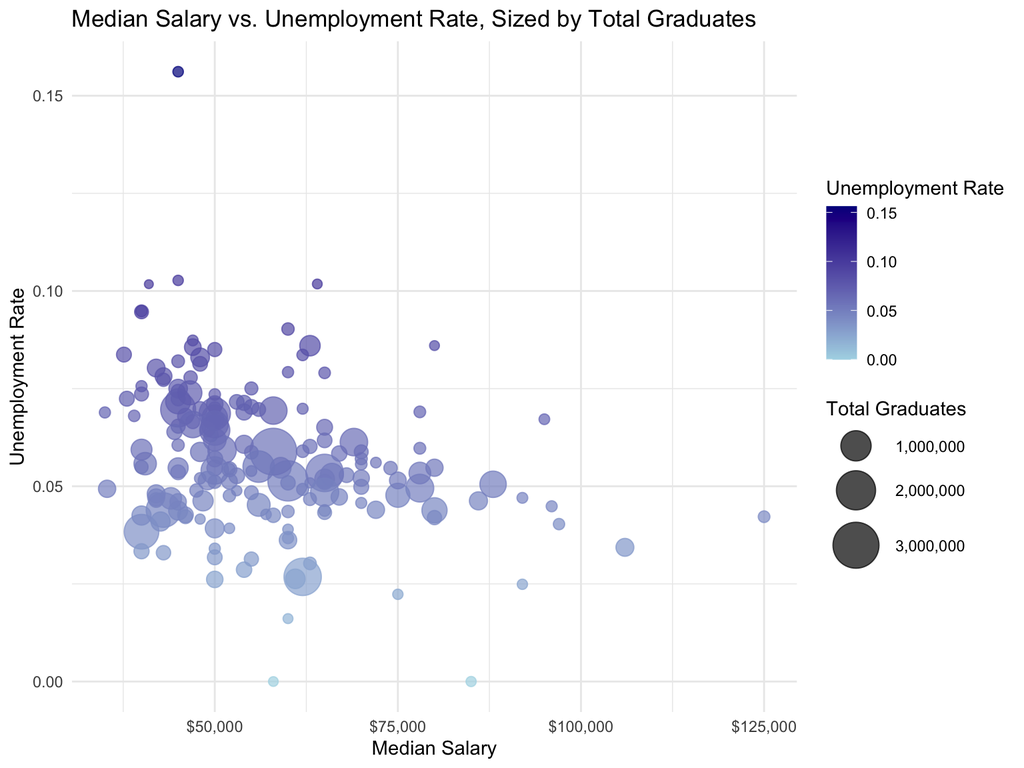

- Higher salaries usually mean lower unemployment, but some exceptions exist.
- Major size isn’t a guarantee of job security.

# Top 10 highest-paying majors

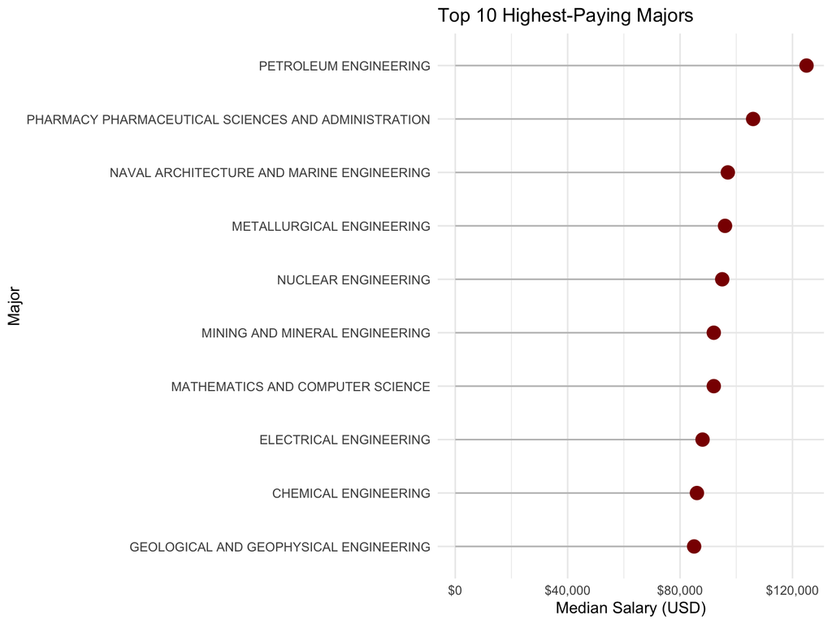

- Engineering and Computer Science dominate the top-paying majors.
- Healthcare fields also appear in the top 10.
- Even within the top 10, Engineering-related majors stand out with noticeably higher median salaries.

# Total graduates vs. unemployment rate

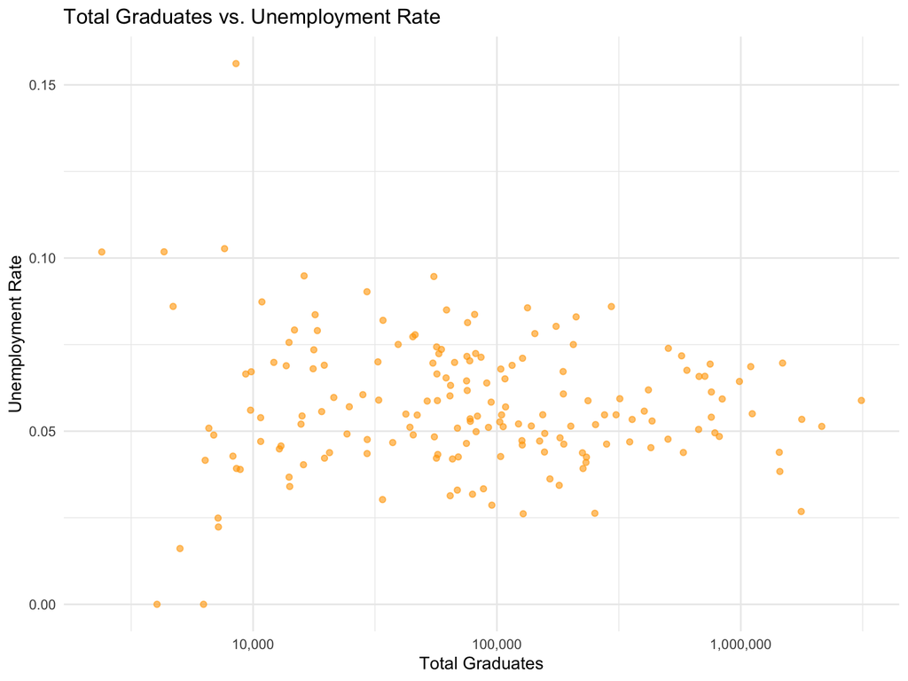

- Smaller majors show more variability in unemployment.
- Larger majors’unemployment rates are more consistent.
- Major size alone does not determine job security.

# Salary Range: P25–P75 by Major

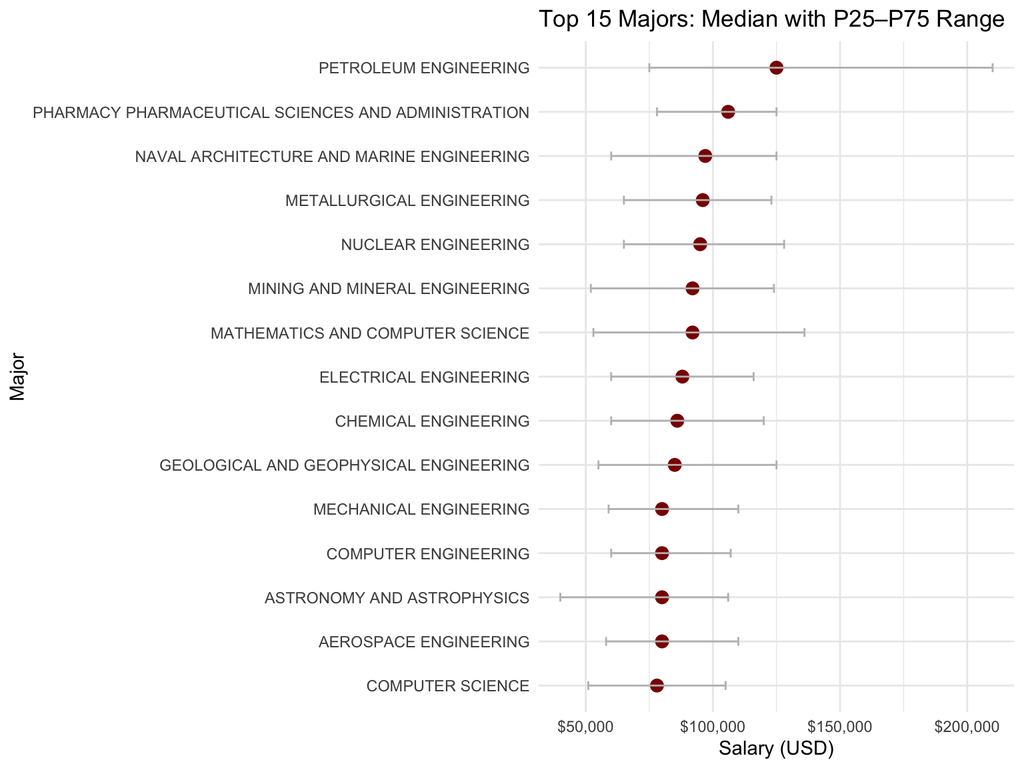

- Shows median salary and P25–P75 range for top 15 majors.
- Technical/Engineering fields have the widest ranges.
- Highlights variability in earnings within each major.

# Median Salary vs Share of Women in STEM

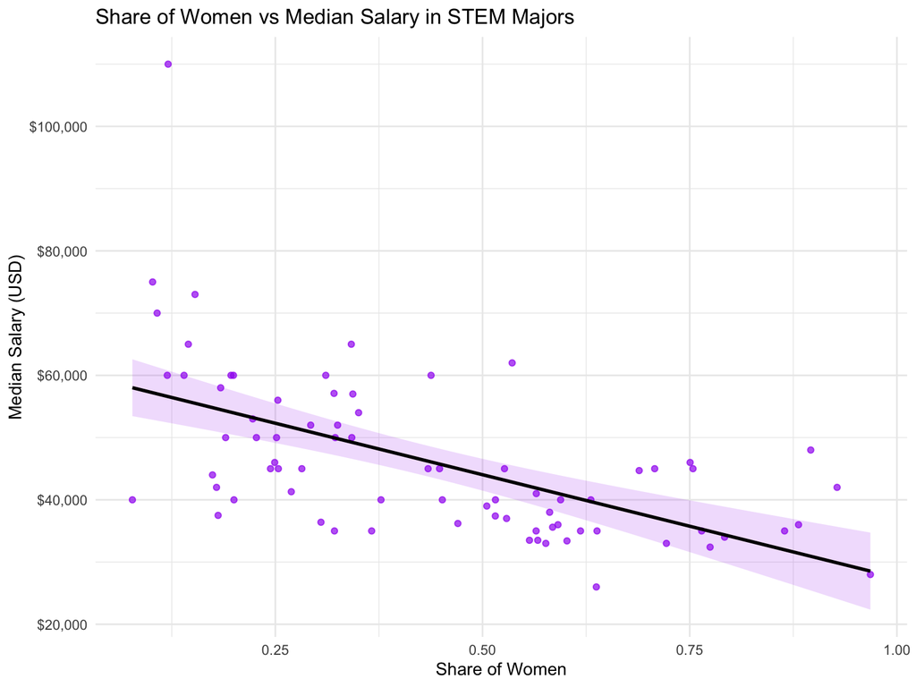

# Unemployment: All Workers vs Recent Graduates

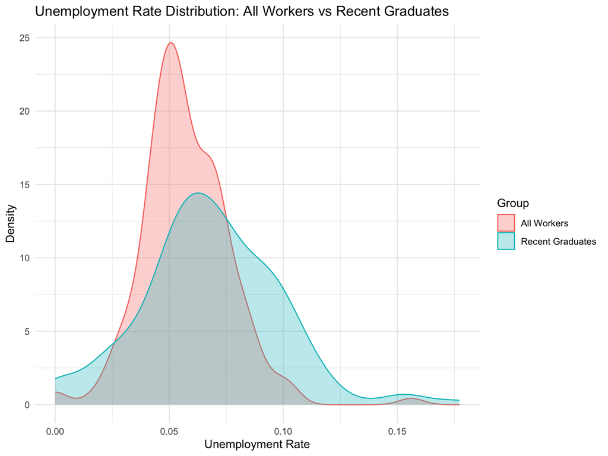

- Compares unemployment rate distributions for all workers vs recent graduates.
- Recent graduates tend to have slightly higher unemployment.
- Some fields remain consistently low or high regardless of experience.

# Summary & Key Insights